# Capstone Project

Ryan Tang

2024-05-31

## Case Study 2: How Can a Wellness Technology Company Play It Smart?

### Introduction

**Scenario:** You are a junior data analyst working on the marketing analyst team at Bellabeat, a high-tech manufacturer of health-focused products for women. Bellabeat is a successful small company, but they have the potential to become a larger player in the global smart device market. Urška Sršen, cofounder and Chief Creative Officer of Bellabeat, believes that analyzing smart device fitness data could help unlock new growth opportunities for the company. You have been asked to focus on one of Bellabeat’s products and analyze smart device data to gain insight into how consumers are using their smart devices. The insights you discover will then help guide marketing strategy for the company. You will present your analysis to the Bellabeat executive team along with your high-level recommendations for Bellabeat’s marketing strategy.

### Phase 1: Ask

**Guiding/Research Questions:** 1. What are some trends in smart device usage? 2. How could these trends apply to Bellabeat customers? 3. How could these trends help influence Bellabeat marketing strategy?

**Key stakeholders:** Urška Sršen (Co-founder and CCO), Sando Mur (Co-founder and executive member), Bellabeat marketing analytics team.

**Business Task:** Bellabeats have the potential to become a larger player in the global smart device market. With its vast consumer database, a thorough analysis of it would unlock new growth opportunities for Bellabeats to be reach its potential as a large smart device market contender by informing its marketing strategies.

**Objective:** Analyze the consumer usage data of non-Bellabeat smart devices (Fitbit Fitness Tracker Data) to identify key trends and patterns. Use these insights to inform marketing strategies for Bellabeat’s products, with a focus on enhancing consumer engagement and driving growth in the global smart device market.

### Phase 2: Prepare

**Data Source:** The FitBit Fitness Tracker Data was downloaded and stored locally from [Kaggle](https://www.kaggle.com/datasets/arashnic/fitbit) under the CC0: Public Domain license. This Kaggle data set contains personal fitness tracker from thirty fitbit users that gave their consent to have their data recorded.

**Data Description:** The data was organized and separated into two folders containing data from 12/3/2016 to 12/4/2016 and 12/4/20116 to 12/5/2016. Within each folder, the data was further separated into 11 csv files containing various information such as heartrate, hourly steps, and calories burned. The data is in a long format, where each row contains a single data point for a particular individual and is repetitive.

**Data Integrity, Credibility, and Bias:** Does it ROCCC (Reliable, Original, Comprehensive, Current, Cited)?

- *Reliable:* Low, this data only consisted of 30 participants which is not representative of the population and may consist of sample selection bias
- *Original:* Low, this data was collected from a third party (Amazon Mechanical Turk) which cast doubt on its integrity.
- *Comprehensive:* Moderate, the data contains a variety of information that may be useful in answering the business task.
- *Current:* Low, the data may be outdated as it was recorded in 2016, though it is worthy to note that is updated annually.
- *Cited:* Low, similarly the data was collected from a third party and thus its credibility cannot be confirmed

### Phase 3: Process

The dailyActivity_merged.csv file will be imported in RStudio for cleaning and analysis.

#### Load libraries

```r
library(tidyverse)
library(skimr)
library(janitor)
```

#### Import dataset

```r
dailyact <- read.csv("dailyActivity_merged.csv")
```

#### View dataset

```r
head(dailyact)
```

```
##           Id ActivityDate TotalSteps TotalDistance TrackerDistance
## 1 1503960366    3/25/2016      11004          7.11            7.11
## 2 1503960366    3/26/2016      17609         11.55           11.55
## 3 1503960366    3/27/2016      12736          8.53            8.53
## 4 1503960366    3/28/2016      13231          8.93            8.93
## 5 1503960366    3/29/2016      12041          7.85            7.85
## 6 1503960366    3/30/2016      10970          7.16            7.16
##   LoggedActivitiesDistance VeryActiveDistance ModeratelyActiveDistance
## 1                        0               2.57                     0.46
## 2                        0               6.92                     0.73
## 3                        0               4.66                     0.16
## 4                        0               3.19                     0.79
## 5                        0               2.16                     1.09
## 6                        0               2.36                     0.51
##   LightActiveDistance SedentaryActiveDistance VeryActiveMinutes
## 1                4.07                       0                33
## 2                3.91                       0                89
## 3                3.71                       0                56
## 4                4.95                       0                39
## 5                4.61                       0                28
## 6                4.29                       0                30
##   FairlyActiveMinutes LightlyActiveMinutes SedentaryMinutes Calories
## 1                  12                  205              804     1819
## 2                  17                  274              588     2154
## 3                   5                  268              605     1944
## 4                  20                  224             1080     1932
## 5                  28                  243              763     1886
## 6                  13                  223             1174     1820
```

#### Data summaries/preview

```r
skim_without_charts(dailyact)
```

Data summary

| Name | dailyact |
| --- | --- |
| Number of rows | 457 |
| Number of columns | 15 |
| _______________________ |  |
| Column type frequency: |  |
| character | 1 |
| numeric | 14 |
| ________________________ |  |
| Group variables | None |

**Variable type: character**

| skim_variable | n_missing | complete_rate | min | max | empty | n_unique | whitespace |
| --- | --- | --- | --- | --- | --- | --- | --- |
| ActivityDate | 0 | 1 | 8 | 9 | 0 | 32 | 0 |

**Variable type: numeric**

| skim_variable | n_missing | complete_rate | mean | sd | p0 | p25 | p50 | p75 | p100 |
| --- | --- | --- | --- | --- | --- | --- | --- | --- | --- |
| Id | 0 | 1 | 4.628595e+09 | 2.293781e+09 | 1503960366 | 2.347168e+09 | 4.057193e+09 | 6.391747e+09 | 8.877689e+09 |
| TotalSteps | 0 | 1 | 6.546560e+03 | 5.398490e+03 | 0 | 1.988000e+03 | 5.986000e+03 | 1.019800e+04 | 2.849700e+04 |
| TotalDistance | 0 | 1 | 4.660000e+00 | 4.080000e+00 | 0 | 1.410000e+00 | 4.090000e+00 | 7.160000e+00 | 2.753000e+01 |
| TrackerDistance | 0 | 1 | 4.610000e+00 | 4.070000e+00 | 0 | 1.280000e+00 | 4.090000e+00 | 7.110000e+00 | 2.753000e+01 |
| LoggedActivitiesDistance | 0 | 1 | 1.800000e-01 | 8.500000e-01 | 0 | 0.000000e+00 | 0.000000e+00 | 0.000000e+00 | 6.730000e+00 |
| VeryActiveDistance | 0 | 1 | 1.180000e+00 | 2.490000e+00 | 0 | 0.000000e+00 | 0.000000e+00 | 1.310000e+00 | 2.192000e+01 |
| ModeratelyActiveDistance | 0 | 1 | 4.800000e-01 | 8.300000e-01 | 0 | 0.000000e+00 | 2.000000e-02 | 6.700000e-01 | 6.400000e+00 |
| LightActiveDistance | 0 | 1 | 2.890000e+00 | 2.240000e+00 | 0 | 8.700000e-01 | 2.930000e+00 | 4.460000e+00 | 1.251000e+01 |
| SedentaryActiveDistance | 0 | 1 | 0.000000e+00 | 1.000000e-02 | 0 | 0.000000e+00 | 0.000000e+00 | 0.000000e+00 | 1.000000e-01 |
| VeryActiveMinutes | 0 | 1 | 1.662000e+01 | 2.892000e+01 | 0 | 0.000000e+00 | 0.000000e+00 | 2.500000e+01 | 2.020000e+02 |
| FairlyActiveMinutes | 0 | 1 | 1.307000e+01 | 3.621000e+01 | 0 | 0.000000e+00 | 1.000000e+00 | 1.600000e+01 | 6.600000e+02 |
| LightlyActiveMinutes | 0 | 1 | 1.700700e+02 | 1.222100e+02 | 0 | 6.400000e+01 | 1.810000e+02 | 2.570000e+02 | 7.200000e+02 |
| SedentaryMinutes | 0 | 1 | 9.952800e+02 | 3.370200e+02 | 32 | 7.280000e+02 | 1.057000e+03 | 1.285000e+03 | 1.440000e+03 |
| Calories | 0 | 1 | 2.189450e+03 | 8.154800e+02 | 0 | 1.776000e+03 | 2.062000e+03 | 2.667000e+03 | 4.562000e+03 |

#### Identify column names

```r
colnames(dailyact)
```

```
##  [1] "Id"                       "ActivityDate"
##  [3] "TotalSteps"               "TotalDistance"
##  [5] "TrackerDistance"          "LoggedActivitiesDistance"
##  [7] "VeryActiveDistance"       "ModeratelyActiveDistance"
##  [9] "LightActiveDistance"      "SedentaryActiveDistance"
## [11] "VeryActiveMinutes"        "FairlyActiveMinutes"
## [13] "LightlyActiveMinutes"     "SedentaryMinutes"
## [15] "Calories"
```

Based on the overview above, it seems that our data contains no null values which is great. Let’s take a closer look at our data types.

#### Check data types

```r
glimpse(dailyact)
```

```
## Rows: 457
## Columns: 15
## $ Id                       <dbl> 1503960366, 1503960366, 1503960366, 150396036…
## $ ActivityDate             <chr> "3/25/2016", "3/26/2016", "3/27/2016", "3/28/…
## $ TotalSteps               <int> 11004, 17609, 12736, 13231, 12041, 10970, 122…
## $ TotalDistance            <dbl> 7.11, 11.55, 8.53, 8.93, 7.85, 7.16, 7.86, 7.…
## $ TrackerDistance          <dbl> 7.11, 11.55, 8.53, 8.93, 7.85, 7.16, 7.86, 7.…
## $ LoggedActivitiesDistance <dbl> 0, 0, 0, 0, 0, 0, 0, 0, 0, 0, 0, 0, 0, 0, 0, …
## $ VeryActiveDistance       <dbl> 2.57, 6.92, 4.66, 3.19, 2.16, 2.36, 2.29, 3.3…
## $ ModeratelyActiveDistance <dbl> 0.46, 0.73, 0.16, 0.79, 1.09, 0.51, 0.49, 0.8…
## $ LightActiveDistance      <dbl> 4.07, 3.91, 3.71, 4.95, 4.61, 4.29, 5.04, 3.6…
## $ SedentaryActiveDistance  <dbl> 0.00, 0.00, 0.00, 0.00, 0.00, 0.00, 0.00, 0.0…
## $ VeryActiveMinutes        <int> 33, 89, 56, 39, 28, 30, 33, 47, 40, 15, 43, 3…
## $ FairlyActiveMinutes      <int> 12, 17, 5, 20, 28, 13, 12, 21, 11, 30, 18, 18…
## $ LightlyActiveMinutes     <int> 205, 274, 268, 224, 243, 223, 239, 200, 244, …
## $ SedentaryMinutes         <int> 804, 588, 605, 1080, 763, 1174, 820, 866, 636…
## $ Calories                 <int> 1819, 2154, 1944, 1932, 1886, 1820, 1889, 186…
```

Based on the summary above, it seems that the “ActivityDate” column is coded as a character type when it should be a date type. We should change that.

```r
dailyact$ActivityDate <- as.Date(dailyact$ActivityDate, "%m/%d/%Y")
```

That looks better. To be able to gain more insights from this data, we can extract even more information from the date data type.

```r
dailyact <- dailyact %>%
  mutate(Month = format(ActivityDate, "%m")) %>%
  mutate(Day = format(ActivityDate, "%d")) %>%
  mutate(Day_of_week = wday(ActivityDate, label=TRUE))
```

To make our column names more consistent and appropriate for analysis, we will use the clean_names() function.

```r
dailyact <- dailyact %>%
  clean_names()
```

### Phase 4: Analyze

Now that our data is cleaned, we can start analyzing it and getting some summary statistics.

#### Check observations

```r
n_distinct(dailyact$id)
```

```
## [1] 35
```

Contrary to the data description, there are 35 distinct user ids. Let’s take a closer look at the summary statistics

#### View summary statistics

```r
dailyact %>%
  select(total_steps, total_distance,very_active_distance,
         moderately_active_distance, light_active_distance,
         sedentary_active_distance, very_active_minutes,
         fairly_active_minutes, lightly_active_minutes,
         sedentary_minutes, calories) %>%
  summary()
```

```
##   total_steps    total_distance   very_active_distance
##  Min.   :    0   Min.   : 0.000   Min.   : 0.000
##  1st Qu.: 1988   1st Qu.: 1.410   1st Qu.: 0.000
##  Median : 5986   Median : 4.090   Median : 0.000
##  Mean   : 6547   Mean   : 4.664   Mean   : 1.181
##  3rd Qu.:10198   3rd Qu.: 7.160   3rd Qu.: 1.310
##  Max.   :28497   Max.   :27.530   Max.   :21.920
##  moderately_active_distance light_active_distance sedentary_active_distance
##  Min.   :0.0000             Min.   : 0.00         Min.   :0.000000
##  1st Qu.:0.0000             1st Qu.: 0.87         1st Qu.:0.000000
##  Median :0.0200             Median : 2.93         Median :0.000000
##  Mean   :0.4786             Mean   : 2.89         Mean   :0.001904
##  3rd Qu.:0.6700             3rd Qu.: 4.46         3rd Qu.:0.000000
##  Max.   :6.4000             Max.   :12.51         Max.   :0.100000
##  very_active_minutes fairly_active_minutes lightly_active_minutes
##  Min.   :  0.00      Min.   :  0.00        Min.   :  0.0
##  1st Qu.:  0.00      1st Qu.:  0.00        1st Qu.: 64.0
##  Median :  0.00      Median :  1.00        Median :181.0
##  Mean   : 16.62      Mean   : 13.07        Mean   :170.1
##  3rd Qu.: 25.00      3rd Qu.: 16.00        3rd Qu.:257.0
##  Max.   :202.00      Max.   :660.00        Max.   :720.0
##  sedentary_minutes    calories
##  Min.   :  32.0    Min.   :   0
##  1st Qu.: 728.0    1st Qu.:1776
##  Median :1057.0    Median :2062
##  Mean   : 995.3    Mean   :2189
##  3rd Qu.:1285.0    3rd Qu.:2667
##  Max.   :1440.0    Max.   :4562
```

Based on these statistics, it seems that this sample of users are fairly active performing an average of 6547 steps per day while burning 2189 calories on average. However, they do spend most of their time doing sedentary activities at an average of 995.3 minutes compared to just 170.1, 13.07, and 16.62 minutes being lightly active, fairly active, and very active respectively.

#### Grouped descriptive statistics

```r
dailyact %>%
  group_by(day_of_week) %>%
  summarise(average_steps = mean(total_steps),
            average_calories = mean(calories))
```

```
## # A tibble: 7 × 3
##   day_of_week average_steps average_calories
##   <ord>               <dbl>            <dbl>
## 1 Sun                 6058.            2168.
## 2 Mon                 7119.            2253.
## 3 Tue                 4915.            1742.
## 4 Wed                 7511.            2377.
## 5 Thu                 6847.            2298.
## 6 Fri                 6738.            2314.
## 7 Sat                 7090.            2278.
```

#### More grouped descriptive statistics

```r
dailyact %>%
  group_by(day_of_week) %>%
  summarise(average_active = mean(very_active_minutes),
            average_fairly_active = mean(fairly_active_minutes),
            average_lightly_active = mean(lightly_active_minutes),
            average_sedentary = mean(sedentary_minutes))
```

```
## # A tibble: 7 × 5
##   day_of_week average_active average_fairly_active average_lightly_active
##   <ord>                <dbl>                 <dbl>                  <dbl>
## 1 Sun                   15.3                  9.21                   164.
## 2 Mon                   19.0                 10.4                    172.
## 3 Tue                   13.2                  8.84                   135.
## 4 Wed                   17.0                 14.5                    190.
## 5 Thu                   17.4                 14.5                    167.
## 6 Fri                   16                   22.2                    178.
## 7 Sat                   19.0                 12.6                    190.
## # ℹ 1 more variable: average_sedentary <dbl>
```

Similarly, activity also tends to be consistent throughout the week with the sample being particularly less active on Tuesdays and more active towards the weekend.

### Phase 5: Share

Now that our dataset is properly cleaned and prepared, it is now time to create our visualizations.

#### Creating visualization 1

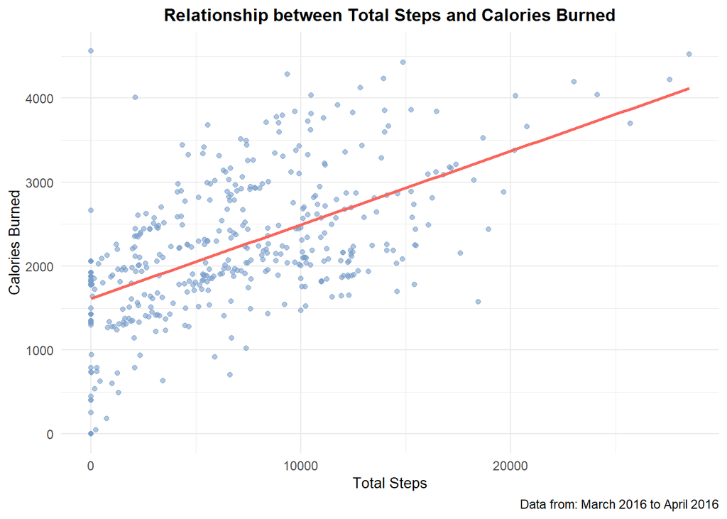

```r
ggplot(dailyact, mapping=aes(x = total_steps, y = calories)) +
  geom_point(color = '#799FCB', alpha = 0.6) +
  geom_smooth(method = 'lm', color = '#F9665E', se = FALSE) +
  labs(title = 'Relationship between Total Steps and Calories Burned',
       caption = 'Data from: March 2016 to April 2016',
       x = 'Total Steps',
       y = 'Calories Burned') +
  theme_minimal() +
  theme(
    plot.title = element_text(hjust = 0.5, size = 12, face = 'bold'),
    axis.title = element_text(size = 10),
    axis.text = element_text(size = 9)
  )
```

Based on visualization 1, there is a clear positive relationship between total steps and calories burned. We can infer from this sample that the more steps an individual takes, the more calories they will burn. It seems obvious, but establishing this baseline relationship will bring more meaning to our following visualizations.

#### Creating visualization 2

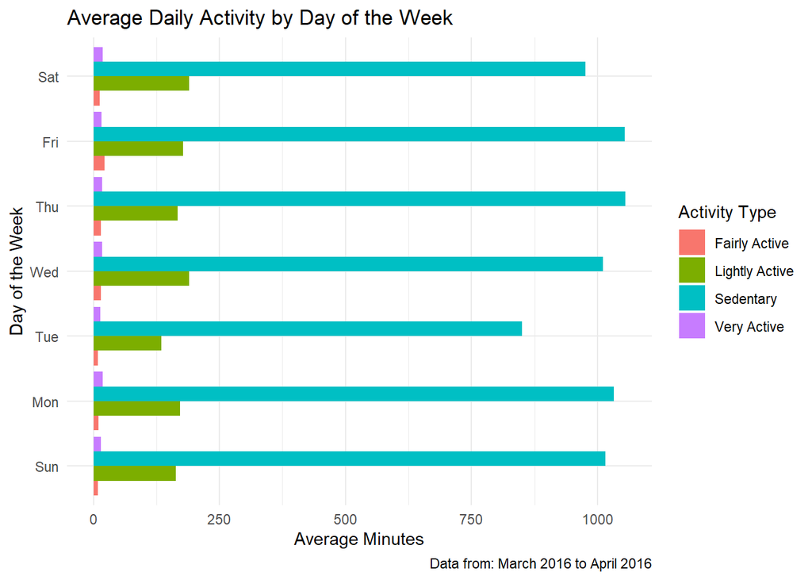

```r
#Get summary data
summary_data <- dailyact %>%
  group_by(day_of_week) %>%
  summarise(average_active = mean(very_active_minutes, na.rm = TRUE),
    average_fairly_active = mean(fairly_active_minutes, na.rm = TRUE),
    average_lightly_active = mean(lightly_active_minutes, na.rm =
    TRUE), average_sedentary = mean(sedentary_minutes, na.rm = TRUE))

#Reshape into long format
long_data <- summary_data %>%
  pivot_longer(cols = starts_with("average_"), names_to = "activity_type", values_to = "average_minutes")

#Rename for better readability
long_data$activity_type <- recode(long_data$activity_type, "average_active" = "Very Active", "average_fairly_active" = "Fairly Active", "average_lightly_active" = "Lightly Active", "average_sedentary" = "Sedentary")

#Plot graph
ggplot(long_data, aes(x = day_of_week, y = average_minutes, fill = activity_type)) +
  geom_bar(stat = "identity", position = position_dodge()) +
  coord_flip() +
  labs(title = 'Average Daily Activity by Day of the Week', caption = 'Data from: March 2016 to April 2016', x = 'Day of the Week', y = 'Average Minutes', fill = 'Activity Type') +
  theme_minimal()
```

Based on visualization 2, this sample seems to spend most of their time throughout the week doing sedentary activities, followed by lightly active activities. This pattern is consistent and renders fairly active and very active times to be insignificant in this context. Therefore, we will focus on these sedentary and lightly active times moving forward.

#### Creating visualization 3

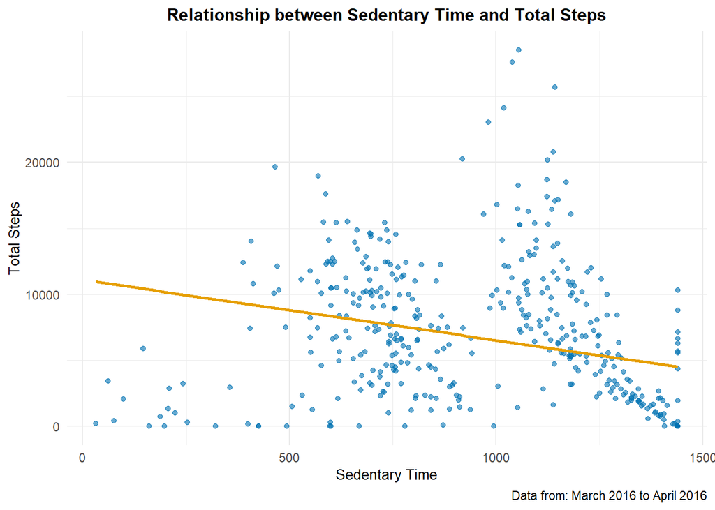

```r
ggplot(dailyact, mapping=aes(x = sedentary_minutes, y = total_steps)) +
  geom_point(color = '#0072B2', alpha = 0.6) +
  geom_smooth(method = 'lm', color = '#E69F00', se = FALSE) +
  labs(title = 'Relationship between Sedentary Time and Total Steps', caption = 'Data from: March 2016 to April 2016', x = 'Sedentary Time', y = 'Total Steps') +
  theme_minimal() +
  theme(
    plot.title = element_text(hjust = 0.5, size = 12, face = 'bold'),
    axis.title = element_text(size = 10),
    axis.text = element_text(size = 9)
  )
```

Based on visualization 3, there is a negative relationship between sedentary time and total steps such that the more sedentary activities that one engages in, the less steps they will take.

#### Creating visualization 4

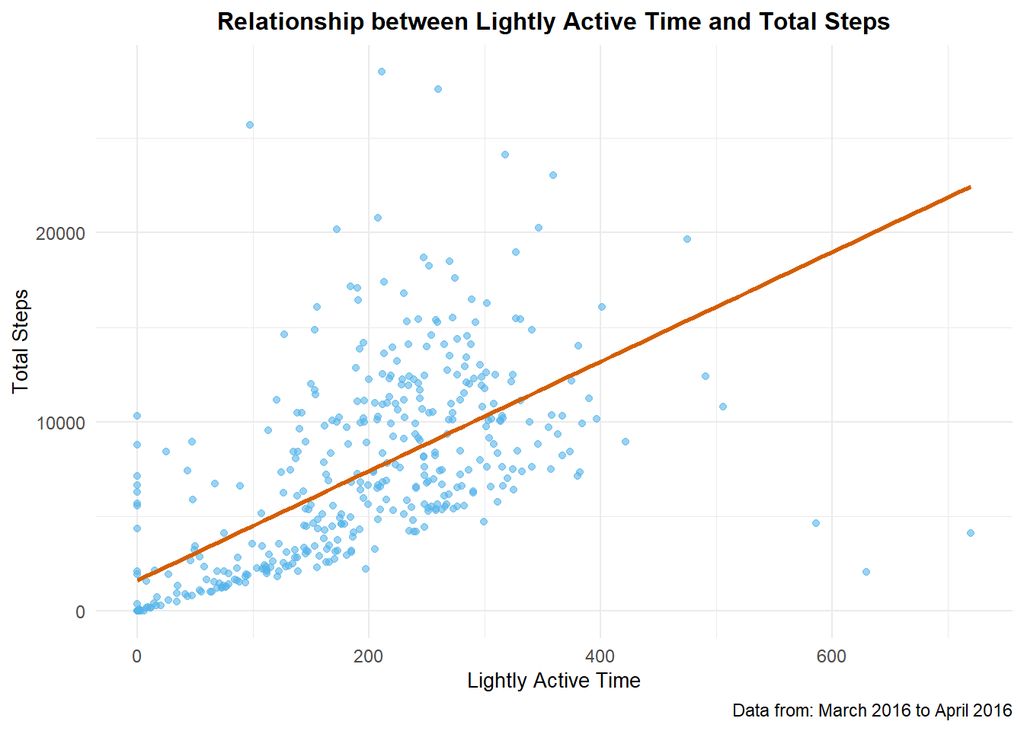

```r
ggplot(dailyact, mapping=aes(x = lightly_active_minutes, y = total_steps)) +
  geom_point(color = '#56B4E9', alpha = 0.6) +
  geom_smooth(method = 'lm', color = '#D55E00', se = FALSE) +
  labs(title = 'Relationship between Lightly Active Time and Total Steps', caption = 'Data from: March 2016 to April 2016', x = 'Lightly Active Time', y = 'Total Steps') +
  theme_minimal() +
  theme(
    plot.title = element_text(hjust = 0.5, size = 12, face = 'bold'),
    axis.title = element_text(size = 10),
    axis.text = element_text(size = 9)
  )
```

Based on visualization 4, there seems to be a strong positive relationship between lightly active time and total steps such that the more lightly active activities an individual engages in, the more steps they will take.

## Phase 6: Act

Great! We now have our visualizations and insight drawn from them. Now, here are our recommendations for Bellabeat based on our analysis.

- Create compelling marketing content that emphasizes how increasing daily step count can significantly contribute to calorie burning and overall health improvement. Run campaigns that challenge users to increase their daily step count with slogans like “Step Up for Health” or “Every Step Counts.” Use testimonials or success stories to show real-life examples of individuals who have benefited from increasing their daily steps.
- Encourage users to incorporate more lightly active activities into their daily routines. Create content that offers practical tips on how to integrate lightly active habits into everyday life, such as taking the stairs instead of the elevator, walking during phone calls, or having walking meetings.
- Develop educational content that explains the benefits of various activity levels. This could include blog posts, videos, infographics, and in-app content that educate users on why it’s important to stay active and how it affects their health.